# Feature_Engineering

### 项目来源：

**由Datawhale与天池联合发起的0基础入门系列赛事第一场 —— 零基础入门数据挖掘之二手车交易价格预测大赛。可以在[这里](https://tianchi.aliyun.com/competition/entrance/231784/introduction)看到**

### 项目目标：

- **赛题以二手车市场为背景，要求选手预测二手汽车的交易价格，这是一个典型的回归问题。通过这道赛题来引导大家走进AI数据竞赛的世界，主要针对于于竞赛新人进行自我练习、自我提高。**，
- **为了更好的引导大家入门，Datawhale同时为本赛题定制了系列学习方案，其中包括数据科学库、通用流程和baseline方案学习三部分。通过对本方案的完整学习，可以帮助掌握数据竞赛基本技能。同时我们也将提供专属的视频直播学习通道。**

### 项目介绍：

- **受监督问题**： 我们可以知道数据的特征和目标，我们的目标是训练可以学习两者之间映射关系的模型。
- **回归问题**： 二手车交易价格是一个连续变量。

### 数据属性说明

| **Filed** | **Description** |
| --- | --- |
| SaleID | 交易ID，唯一编码 |
| name | 汽车交易名称，已脱敏 |
| regDate | 汽车注册日期，例如20160101，2016年01月01日 |
| model | 车型编码，已脱敏 |
| brand | 汽车品牌，已脱敏 |
| bodyType | 车身类型：豪华轿车：0，微型车：1，厢型车：2，大巴车：3，敞篷车：4，双门汽车：5，商务车：6，搅拌车：7 |
| fuelType | 燃油类型：汽油：0，柴油：1，液化石油气：2，天然气：3，混合动力：4，其他：5，电动：6 |
| gearbox | 变速箱：手动：0，自动：1 |
| power | 发动机功率：范围[0, 600] |
| kilometer | 汽车已行驶公里，单位万km |
| notRepairedDamage | 汽车有尚未修复的损坏：是：0，否：1 |
| regionCode | 地区编码，已脱敏 |
| seller | 销售方：个体：0，非个体：1 |
| offerType | 报价类型：提供：0，请求：1 |
| createDate | 汽车上线时间，即开始售卖时间 |
| price | 二手车交易价格（预测目标） |
| v系列特征 | 匿名特征，包含v0-14在内15个匿名特征 |

# Machine Learning Workflow

我们在**拿到一个机器学习问题之后，要做的第一件事就是制作出我们的机器学习项目清单**。下面给出了一个可供参考的机器学习项目清单，它应该适用于大多数机器学习项目，虽然确切的实现细节可能有所不同，但机器学习项目的一般结构保持相对稳定：

1. 数据清理和格式化
2. 探索性数据分析
3. 特征工程和特征选择
4. 基于性能指标比较几种机器学习模型
5. 对最佳模型执行超参数调整
6. 在测试集上评估最佳模型
7. 解释模型结果
8. 得出结论

提前设置机器学习管道结构让我们看到每一步是如何流入另一步的。但是，机器学习管道是一个迭代过程，因此我们并不总是以线性方式遵循这些步骤。我们可能会根据管道下游的结果重新审视上一步。例如，

- 虽然我们可以在构建任何模型之前执行特征选择，但我们可以使用建模结果返回并选择一组不同的特征。
- 或者，建模可能会出现意想不到的结果，这意味着我们希望从另一个角度探索我们的数据。
- 一般来说，你必须完成一步才能继续下一步，但不要觉得一旦你第一次完成一步，你就不能回头做出改进！你可以在任何时候返回前面的步骤并作出相应的修改

# Imports

使用标准的数据科学和机器学习库：`numpy，pandas`和`scikit-learn`。 使用`matplotlib`和`seaborn`进行可视化。

```python
# 用于数据操作的pandas和numpy
import pandas as pd
import numpy as np

# 不显示关于在切片副本上设置值的警告
pd.options.mode.chained_assignment = None

# 一个dataframe 最多显示60例样本
pd.set_option('display.max_columns', 60)

# 可视化工具包
import matplotlib.pyplot as plt
%matplotlib inline

# 设置默认字体大小
plt.rcParams['font.size'] = 24

# 导入设置图片大小的工具
from IPython.core.pylabtools import figsize

# 导入用于可视化的Seaborn
import seaborn as sns
sns.set(font_scale = 2)

# 把数据分为训练集和测试集

from sklearn.model_selection import train_test_split

import math
```

# 数据清理和格式化

## 加载并检查数据

我们把数据加载到pandas数据帧中，这是数据科学最有用的数据结构之一。将其视为Python中的电子表格，我们可以轻松地操作，清理和可视化。[Pandas有许多方法](https://pandas.pydata.org/pandas-docs/stable/)可以帮助使数据科学/机器学习管道尽可能顺利。

```python
# 把数据读入pandas dataframe
data = pd.read_csv('used_car_train_20200313.csv', sep=' ')

# 显示表头
data.head()
```

|  | SaleID | name | regDate | model | brand | bodyType | fuelType | gearbox | power | kilometer | notRepairedDamage | regionCode | seller | offerType | creatDate | price | v_0 | v_1 | v_2 | v_3 | v_4 | v_5 | v_6 | v_7 | v_8 | v_9 | v_10 | v_11 | v_12 | … |
| --- | --- | --- | --- | --- | --- | --- | --- | --- | --- | --- | --- | --- | --- | --- | --- | --- | --- | --- | --- | --- | --- | --- | --- | --- | --- | --- | --- | --- | --- | --- |
| 0 | 0 | 736 | 20040402 | 30.0 | 6 | 1.0 | 0.0 | 0.0 | 60 | 12.5 | 0.0 | 1046 | 0 | 0 | 20160404 | 1850 | 43.357796 | 3.966344 | 0.050257 | 2.159744 | 1.143786 | 0.235676 | 0.101988 | 0.129549 | 0.022816 | 0.097462 | -2.881803 | 2.804097 | -2.420821 | … |
| 1 | 1 | 2262 | 20030301 | 40.0 | 1 | 2.0 | 0.0 | 0.0 | 0 | 15.0 | - | 4366 | 0 | 0 | 20160309 | 3600 | 45.305273 | 5.236112 | 0.137925 | 1.380657 | -1.422165 | 0.264777 | 0.121004 | 0.135731 | 0.026597 | 0.020582 | -4.900482 | 2.096338 | -1.030483 | … |
| 2 | 2 | 14874 | 20040403 | 115.0 | 15 | 1.0 | 0.0 | 0.0 | 163 | 12.5 | 0.0 | 2806 | 0 | 0 | 20160402 | 6222 | 45.978359 | 4.823792 | 1.319524 | -0.998467 | -0.996911 | 0.251410 | 0.114912 | 0.165147 | 0.062173 | 0.027075 | -4.846749 | 1.803559 | 1.565330 | … |
| 3 | 3 | 71865 | 19960908 | 109.0 | 10 | 0.0 | 0.0 | 1.0 | 193 | 15.0 | 0.0 | 434 | 0 | 0 | 20160312 | 2400 | 45.687478 | 4.492574 | -0.050616 | 0.883600 | -2.228079 | 0.274293 | 0.110300 | 0.121964 | 0.033395 | 0.000000 | -4.509599 | 1.285940 | -0.501868 | … |
| 4 | 4 | 111080 | 20120103 | 110.0 | 5 | 1.0 | 0.0 | 0.0 | 68 | 5.0 | 0.0 | 6977 | 0 | 0 | 20160313 | 5200 | 44.383511 | 2.031433 | 0.572169 | -1.571239 | 2.246088 | 0.228036 | 0.073205 | 0.091880 | 0.078819 | 0.121534 | -1.896240 | 0.910783 | 0.931110 | … |

## 数据类型和缺失值

```python
data.info()
```

```
<class 'pandas.core.frame.DataFrame'>
RangeIndex: 150000 entries, 0 to 149999
Data columns (total 31 columns):
SaleID               150000 non-null int64
name                 150000 non-null int64
regDate              150000 non-null int64
model                149999 non-null float64
brand                150000 non-null int64
bodyType             145494 non-null float64
fuelType             141320 non-null float64
gearbox              144019 non-null float64
power                150000 non-null int64
kilometer            150000 non-null float64
notRepairedDamage    150000 non-null object
regionCode           150000 non-null int64
seller               150000 non-null int64
offerType            150000 non-null int64
creatDate            150000 non-null int64
price                150000 non-null int64
v_0                  150000 non-null float64
v_1                  150000 non-null float64
v_2                  150000 non-null float64
v_3                  150000 non-null float64
v_4                  150000 non-null float64
v_5                  150000 non-null float64
v_6                  150000 non-null float64
v_7                  150000 non-null float64
v_8                  150000 non-null float64
v_9                  150000 non-null float64
v_10                 150000 non-null float64
v_11                 150000 non-null float64
v_12                 150000 non-null float64
v_13                 150000 non-null float64
v_14                 150000 non-null float64
dtypes: float64(20), int64(10), object(1)
memory usage: 35.5+ MB
```

对于`notRepairedDamage`列，本该是明确包含数字，但被存储为object类型（对象类型）。我们不能对字符串进行数值分析，因此必须将其转换为数字（特别是浮点数）数据类型。

这里把`notRepairedDamage`列中的不同值进行显示

```python
data['notRepairedDamage'].value_counts()
```

```
0.0    111361
-       24324
1.0     14315
Name: notRepairedDamage, dtype: int64
```

可以看出来`'-'`也应该表示空缺值，**但是从`data.info()`给出的信息上却没有被视为空缺值**，所以先将其替换为nan

```python
data.replace('-', np.nan, inplace=True)
```

### 将数据转换为正确的类型

- 我们首先**将带有数组并且缺失值被编码为`Not Available`的列转换为数字数据特征**，方法是将`Not Available`项替换为可以解释为浮点数的np.nan。
- 然后我们将包含数值的列转换为合理的数字数据类型（将object类转换为数字数据类型）

```python
# 将"Not Available" 项替换为可以解释为浮点数的np.nan
data = data.replace({'Not Available': np.nan})


# 转换某些列的数据类型
for col in list(data.columns):
    # 选择需要被数字化的列，通过if判断实现
    # 凡是包含下列红色字体的列，都是需要被转换的列
    if ('notRepairedDamage' in col):
        # 将数据类型转换为float
        data[col] = data[col].astype(float)
```

```python
data.head()
```

|  | SaleID | name | regDate | model | brand | bodyType | fuelType | gearbox | power | kilometer | notRepairedDamage | regionCode | seller | offerType | creatDate | price | v_0 | v_1 | v_2 | v_3 | v_4 | v_5 | v_6 | v_7 | v_8 | v_9 | v_10 | v_11 | v_12 | … |
| --- | --- | --- | --- | --- | --- | --- | --- | --- | --- | --- | --- | --- | --- | --- | --- | --- | --- | --- | --- | --- | --- | --- | --- | --- | --- | --- | --- | --- | --- | --- |
| 0 | 0 | 736 | 20040402 | 30.0 | 6 | 1.0 | 0.0 | 0.0 | 60 | 12.5 | 0.0 | 1046 | 0 | 0 | 20160404 | 1850 | 43.357796 | 3.966344 | 0.050257 | 2.159744 | 1.143786 | 0.235676 | 0.101988 | 0.129549 | 0.022816 | 0.097462 | -2.881803 | 2.804097 | -2.420821 | … |
| 1 | 1 | 2262 | 20030301 | 40.0 | 1 | 2.0 | 0.0 | 0.0 | 0 | 15.0 | NaN | 4366 | 0 | 0 | 20160309 | 3600 | 45.305273 | 5.236112 | 0.137925 | 1.380657 | -1.422165 | 0.264777 | 0.121004 | 0.135731 | 0.026597 | 0.020582 | -4.900482 | 2.096338 | -1.030483 | … |
| 2 | 2 | 14874 | 20040403 | 115.0 | 15 | 1.0 | 0.0 | 0.0 | 163 | 12.5 | 0.0 | 2806 | 0 | 0 | 20160402 | 6222 | 45.978359 | 4.823792 | 1.319524 | -0.998467 | -0.996911 | 0.251410 | 0.114912 | 0.165147 | 0.062173 | 0.027075 | -4.846749 | 1.803559 | 1.565330 | … |
| 3 | 3 | 71865 | 19960908 | 109.0 | 10 | 0.0 | 0.0 | 1.0 | 193 | 15.0 | 0.0 | 434 | 0 | 0 | 20160312 | 2400 | 45.687478 | 4.492574 | -0.050616 | 0.883600 | -2.228079 | 0.274293 | 0.110300 | 0.121964 | 0.033395 | 0.000000 | -4.509599 | 1.285940 | -0.501868 | … |
| 4 | 4 | 111080 | 20120103 | 110.0 | 5 | 1.0 | 0.0 | 0.0 | 68 | 5.0 | 0.0 | 6977 | 0 | 0 | 20160313 | 5200 | 44.383511 | 2.031433 | 0.572169 | -1.571239 | 2.246088 | 0.228036 | 0.073205 | 0.091880 | 0.078819 | 0.121534 | -1.896240 | 0.910783 | 0.931110 | … |

### 处理缺失值

```python
# 查看每一列存在nan的情况
data.isnull().sum()
```

```
SaleID                   0
name                     0
regDate                  0
model                    1
brand                    0
bodyType              4506
fuelType              8680
gearbox               5981
power                    0
kilometer                0
notRepairedDamage    24324
regionCode               0
seller                   0
offerType                0
creatDate                0
price                    0
v_0                      0
v_1                      0
v_2                      0
v_3                      0
v_4                      0
v_5                      0
v_6                      0
v_7                      0
v_8                      0
v_9                      0
v_10                     0
v_11                     0
v_12                     0
v_13                     0
v_14                     0
dtype: int64
```

我们可以通过查看每列中缺失值的百分比来开始分析。当我们进行探索性数据分析时，缺失值的处理尤其关键，需要通过合理的方法来判断是否进行填充或删除。

以下是一个函数，用于计算缺失值的数量以及每列缺少的总之的百分比。与数据科学中的许多任务一样，我自己没有编写这个函数，而是在在线论坛[Stack Overflow forum](https://stackoverflow.com/a/39734251) 中发现它的！

```python
# 定义按列计算缺失值的函数
def missing_values_table(df):
    # 计算总的缺失值
    mis_val = df.isnull().sum()

    # 计算缺失值的百分比
    mis_val_percent = 100 * mis_val / len(df)

    # 把结果制成表格
    mis_val_table = pd.concat([mis_val, mis_val_percent], axis = 1)

    # 对列重命名，第一列：Missing Values，第二列：% of Total Values
    mis_val_table_ren_columns = mis_val_table.rename(
    columns = {0: 'Missing Values', 1: '% of Total Values'})

    # 根据百分比对表格进行降序排列
    mis_val_table_ren_columns = mis_val_table_ren_columns[
        mis_val_table_ren_columns.iloc[:, 1] != 0].sort_values(
    '% of Total Values', ascending=False).round(1)

    # 打印总结信息：总的列数，有数据缺失的列数
    print("Your selected dataframe has " + str(df.shape[1]) + " columns.\n"
         "There are " + str(mis_val_table_ren_columns.shape[0]) +
         " columns that have missing values.")

    # 返回带有缺失值信息的dataframe
    return mis_val_table_ren_columns
```

```python
missing_values_table(data)
```

```
Your selected dataframe has 31 columns.
There are 5 columns that have missing values.
```

|  | Missing Values | % of Total Values |
| --- | --- | --- |
| notRepairedDamage | 24324 | 16.2 |
| fuelType | 8680 | 5.8 |
| gearbox | 5981 | 4.0 |
| bodyType | 4506 | 3.0 |
| model | 1 | 0.0 |

```python
data.describe()
```

|  | SaleID | name | regDate | model | brand | bodyType | fuelType | gearbox | power | kilometer | notRepairedDamage | regionCode | seller | offerType | creatDate | price | v_0 | v_1 | v_2 | v_3 | v_4 | v_5 | v_6 | v_7 | v_8 | v_9 | v_10 | v_11 | v_12 | … |
| --- | --- | --- | --- | --- | --- | --- | --- | --- | --- | --- | --- | --- | --- | --- | --- | --- | --- | --- | --- | --- | --- | --- | --- | --- | --- | --- | --- | --- | --- | --- |
| count | 150000.000000 | 150000.000000 | 1.500000e+05 | 149999.000000 | 150000.000000 | 145494.000000 | 141320.000000 | 144019.000000 | 150000.000000 | 150000.000000 | 125676.000000 | 150000.000000 | 150000.000000 | 150000.0 | 1.500000e+05 | 150000.000000 | 150000.000000 | 150000.000000 | 150000.000000 | 150000.000000 | 150000.000000 | 150000.000000 | 150000.000000 | 150000.000000 | 150000.000000 | 150000.000000 | 150000.000000 | 150000.000000 | 150000.000000 | … |
| mean | 74999.500000 | 68349.172873 | 2.003417e+07 | 47.129021 | 8.052733 | 1.792369 | 0.375842 | 0.224943 | 119.316547 | 12.597160 | 0.113904 | 2583.077267 | 0.000007 | 0.0 | 2.016033e+07 | 5923.327333 | 44.406268 | -0.044809 | 0.080765 | 0.078833 | 0.017875 | 0.248204 | 0.044923 | 0.124692 | 0.058144 | 0.061996 | -0.001000 | 0.009035 | 0.004813 | … |
| std | 43301.414527 | 61103.875095 | 5.364988e+04 | 49.536040 | 7.864956 | 1.760640 | 0.548677 | 0.417546 | 177.168419 | 3.919576 | 0.317696 | 1885.363218 | 0.002582 | 0.0 | 1.067328e+02 | 7501.998477 | 2.457548 | 3.641893 | 2.929618 | 2.026514 | 1.193661 | 0.045804 | 0.051743 | 0.201410 | 0.029186 | 0.035692 | 3.772386 | 3.286071 | 2.517478 | … |
| min | 0.000000 | 0.000000 | 1.991000e+07 | 0.000000 | 0.000000 | 0.000000 | 0.000000 | 0.000000 | 0.000000 | 0.500000 | 0.000000 | 0.000000 | 0.000000 | 0.0 | 2.015062e+07 | 11.000000 | 30.451976 | -4.295589 | -4.470671 | -7.275037 | -4.364565 | 0.000000 | 0.000000 | 0.000000 | 0.000000 | 0.000000 | -9.168192 | -5.558207 | -9.639552 | … |
| 25% | 37499.750000 | 11156.000000 | 1.999091e+07 | 10.000000 | 1.000000 | 0.000000 | 0.000000 | 0.000000 | 75.000000 | 12.500000 | 0.000000 | 1018.000000 | 0.000000 | 0.0 | 2.016031e+07 | 1300.000000 | 43.135799 | -3.192349 | -0.970671 | -1.462580 | -0.921191 | 0.243615 | 0.000038 | 0.062474 | 0.035334 | 0.033930 | -3.722303 | -1.951543 | -1.871846 | … |
| 50% | 74999.500000 | 51638.000000 | 2.003091e+07 | 30.000000 | 6.000000 | 1.000000 | 0.000000 | 0.000000 | 110.000000 | 15.000000 | 0.000000 | 2196.000000 | 0.000000 | 0.0 | 2.016032e+07 | 3250.000000 | 44.610266 | -3.052671 | -0.382947 | 0.099722 | -0.075910 | 0.257798 | 0.000812 | 0.095866 | 0.057014 | 0.058484 | 1.624076 | -0.358053 | -0.130753 | … |
| 75% | 112499.250000 | 118841.250000 | 2.007111e+07 | 66.000000 | 13.000000 | 3.000000 | 1.000000 | 0.000000 | 150.000000 | 15.000000 | 0.000000 | 3843.000000 | 0.000000 | 0.0 | 2.016033e+07 | 7700.000000 | 46.004721 | 4.000670 | 0.241335 | 1.565838 | 0.868758 | 0.265297 | 0.102009 | 0.125243 | 0.079382 | 0.087491 | 2.844357 | 1.255022 | 1.776933 | … |
| max | 149999.000000 | 196812.000000 | 2.015121e+07 | 247.000000 | 39.000000 | 7.000000 | 6.000000 | 1.000000 | 19312.000000 | 15.000000 | 1.000000 | 8120.000000 | 1.000000 | 0.0 | 2.016041e+07 | 99999.000000 | 52.304178 | 7.320308 | 19.035496 | 9.854702 | 6.829352 | 0.291838 | 0.151420 | 1.404936 | 0.160791 | 0.222787 | 12.357011 | 18.819042 | 13.847792 | … |

# 探索性数据分析（EDA）

[探索性数据分析（EDA）](https://en.wikipedia.org/wiki/Exploratory_data_analysis)是一个开放式流程，我们制作绘图并计算统计数据，以便探索我们的数据。

- 目的是找到异常，模式，趋势或关系。 这些可能是有趣的（例如，找到两个变量之间的相关性），或者它们可用于建模决策，例如使用哪些特征。
- 简而言之，EDA的目标是确定我们的数据可以告诉我们什么！ EDA通常以高级概述(high-level overview)开始，然后在我们找到要检查的感兴趣的区域时缩小到数据集的特定部分。

要开始EDA，我们将专注于单一变量（单个特征或预测目标）。

## 单变量图

单个变量,称为[单变量](https://en.wikipedia.org/wiki/Univariate)（统计）图表显示单个变量的分布，例如直方图。

```python
feature_cols = data.columns.drop('price')
```

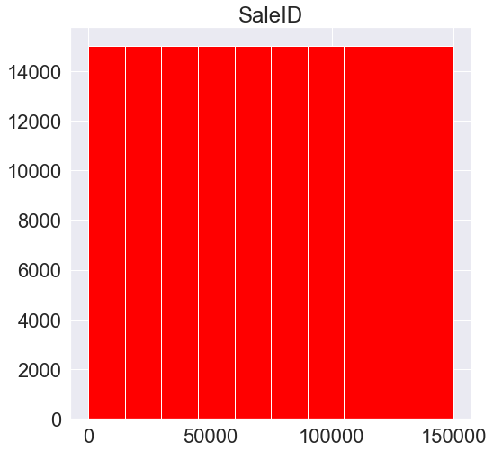

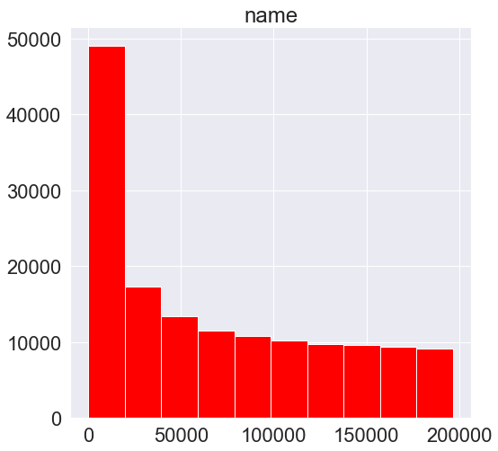

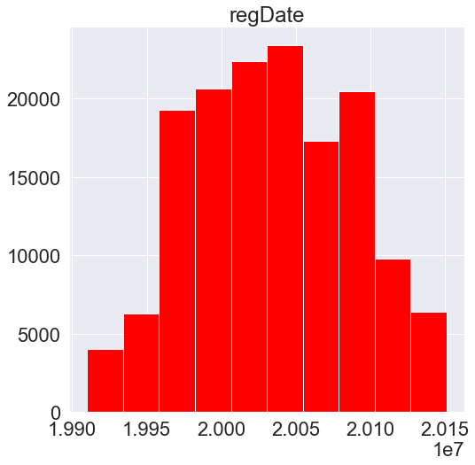

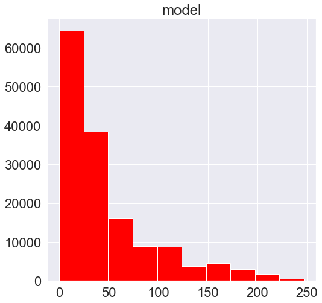

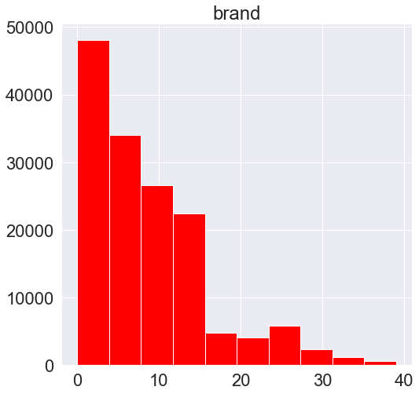

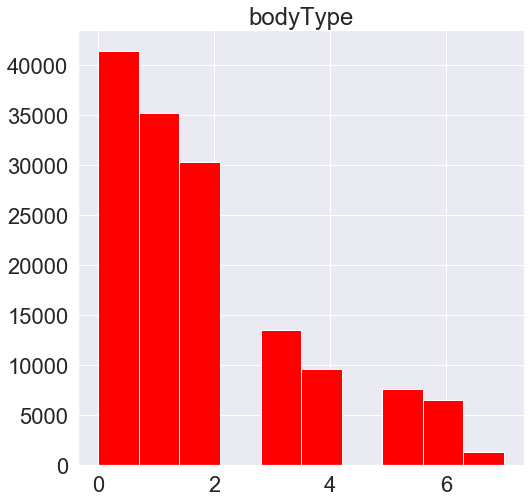

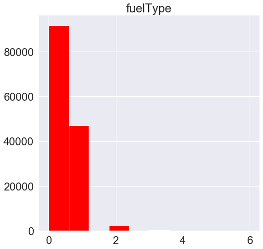

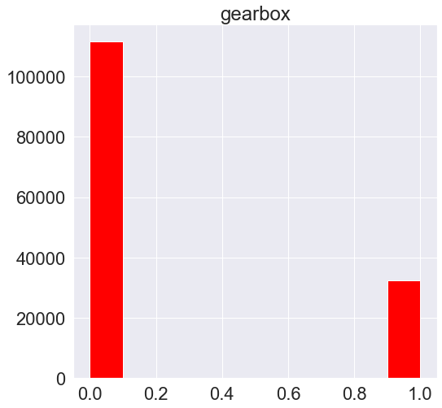

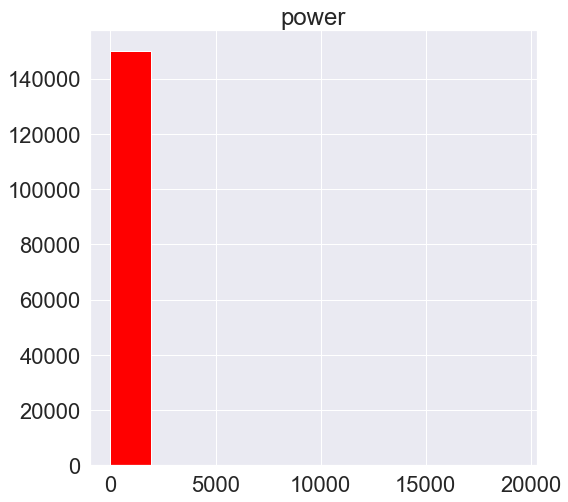

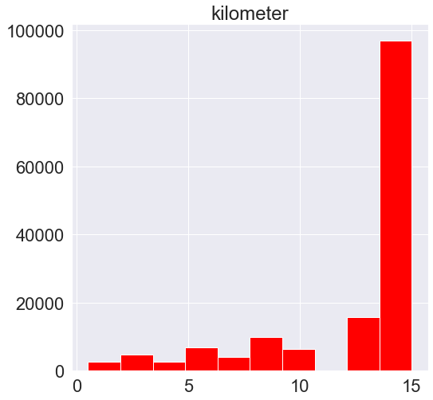

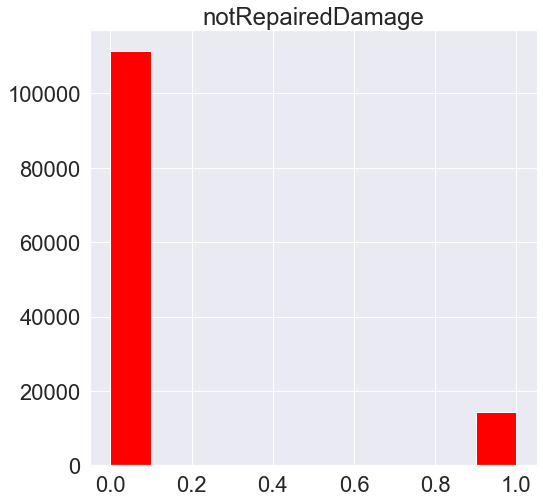

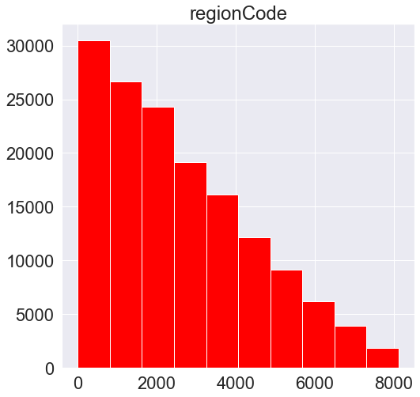

[18 more figures not shown]

```python
figsize(8, 8)

# 为每一个变量绘制直方图
for col in feature_cols:
    plt.hist(data[col], orientation= 'vertical', histtype='bar', color='red')
    plt.title(col)
    plt.show()
```

观察上述单变量图，可以发现特征`fuelType`、`gearbox`、`power`、`notRepairedDamage`、`seller`、`offerTpye`、`createData`、`v_1`、`v_2`、`v_5`、`v_6`、`v_7`、`v_10`、`v_11`的数据分布**可能存在异常**。

```python
abnormal_features = ['fuelType', 'gearbox', 'power', 'notRepairedDamage', 'seller',
                    'offerType', 'creatDate', 'v_1', 'v_2', 'v_5', 'v_6', 'v_7', 'v_10', 'v_11']
```

```python
# 各特征nunique统计
for col in abnormal_features:
    print(col + "的特征分布如下：")
    print("{}特征有个{}不同的值".format(col, data[col].nunique()))
    print(data[col].value_counts())
    print('\n')
```

```
fuelType的特征分布如下：
fuelType特征有个7不同的值
0.0    91656
1.0    46991
2.0     2212
3.0      262
4.0      118
5.0       45
6.0       36
Name: fuelType, dtype: int64


gearbox的特征分布如下：
gearbox特征有个2不同的值
0.0    111623
1.0     32396
Name: gearbox, dtype: int64


power的特征分布如下：
power特征有个566不同的值
0       12829
75       9593
150      6495
60       6374
140      5963
        ...
1597        1
1596        1
572         1
316         1
575         1
Name: power, Length: 566, dtype: int64


notRepairedDamage的特征分布如下：
notRepairedDamage特征有个2不同的值
0.0    111361
1.0     14315
Name: notRepairedDamage, dtype: int64
```

[output cut: 126 more lines]

```

v_11的特征分布如下：
v_11特征有个143997不同的值
-2.255591    20
-0.330053    16
-1.107940    15
-0.802614    15
-1.436494    15
             ..
-2.418401     1
-0.622637     1
 0.195040     1
-0.802083     1
 0.920200     1
Name: v_11, Length: 143997, dtype: int64
```

- 发现特征`seller`和`offerType`的值存在严重倾斜（如`seller`中0有149999个，1只有1个；`offerType`中全为0）有理由认为，这两个特征值对预测结果基本上不起作用，**考虑删除**。
- 特征`creatDate`是和时间有关的特征，可以考虑将其转换为相对时间（一种考虑的方式为联合`regDate`车辆注册时间，计算出相对时间）根据常识，这样的一个时间信息对汽车的售价应该存在某种联系。
- 特征`fuelType`大多数属于类别0或类别1，其他类别的数量差别很大。单从这个特征考虑，数据存在极大的不平衡，具体处理待定。TODO: deal with `fuelType`
- 特征`bearbox`也存在一定的数据不平衡现象。TODO: deal with `bearbox`
- 特征`power`存在异常，从数据格式说明中可以知道`power`的取值范围为[0, 600]，而原数据明显不在此范围内。TODO: deal with `power`
- 特征`notRepairedDamage`不仅存在大量缺失值，还存在数据不平衡问题。TODO: deal with `notRepairedDamage`
- 特征`v_1`、`v_2`、`v_5`、`v_6`、`v_7`、`v_10`、`v_11`均存在"小部分数据离群"，有理由认为是离群点。TODO: deal with `v_1`、`v_2`、`v_5`、`v_6`、`v_7`、`v_10`、`v_11`

### 处理seller和offerType

**不考虑这两列特征，直接删除**

注意：训练数据不考虑这两列特征，那么在预测时，对于测试数据也不考虑这两列特征。

```python
del data["seller"]
del data["offerType"]
```

### 处理creatDate

考虑相对时间，但是发现特征`regDate`中存在不符合yyyymmdd格式的日期，所以在计算相对时间时要用`errors='coerce'`

```python
# 复制'regDate'列，并命名为'Date_Start'
# 复制'creatDate'列，并命名为'Date_End'
# 避免直接在原始数据上计算
# 并将转换为转换为pandas中的日期类型

data['Date_End'] = pd.to_datetime(data['creatDate'], format='%Y%m%d', errors='ignore')

# 查看转换后的结果
# data['Date_End']
# data['Data_Start']
```

```python
# regDate存在不符合yyyymmdd格式的日期
# 利用正则表达式进行过滤
import re

rule = r'^([\d]{4}((((0[13578]|1[02])((0[1-9])|([12][0-9])|(3[01])))|(((0[469])|11)((0[1-9])|([12][0-9])|30))|(02((0[1-9])|(1[0-9])|(2[0-8])))))|((((([02468][048])|([13579][26]))00)|([0-9]{2}(([02468][048])|([13579][26]))))(((0[13578]|1[02])((0[1-9])|([12][0-9])|(3[01])))|(((0[469])|11)((0[1-9])|([12][0-9])|30))|(02((0[1-9])|(1[0-9])|(2[0-9]))))){4})$'

regex = re.compile(rule)

data['Date_copy'] = ' '

for i in range(data['regDate'].shape[0]):
    if regex.match(str(data['regDate'][i])):
        data['Date_copy'][i] = data['regDate'][i]
    else:
        data['Date_copy'][i] = np.nan
```

```python
data['Date_copy'].isnull().sum()
```

```
11347
```

```python
# 同时，查看test数据集中特征`regDate`是否也存在格式不正确的情况
# 读取test数据文件
test = pd.read_csv('used_car_testA_20200313.csv', sep=' ')
```

```python
test['test1'] = ' '

for i in range(test['regDate'].shape[0]):
    if regex.match(str(test['regDate'][i])):
        test['test1'][i] = test['regDate'][i]
    else:
        test['test1'][i] = np.nan
        print('第{}行的日期格式{}不正确'.format(i, test['regDate'][i]))
```

[output not shown]

[output cut: 3699 more lines]

[output not shown]

```python
test['test1'].isnull().sum()
```

```
3754
```

- 训练数据中特征`regDate`存在11347条不符合yyyymmdd格式的日期（缺失具体的月份）
- 测试集中特征`regDate`也存在3754条不符合yyyymmdd格式的日期（缺失具体月份）
- **所以如果想要使用相对时间这一信息，需要对不符合的日期进行修正**，对于特征`regDate`很难有合理的估计方法
- 这里，暂时将格式不符的样本设置为nan，因为目前有许多树模型可以自行处理nan
- 所以在计算相对时间时，设置errors='coerce'

```python
data['used_time'] = (pd.to_datetime(data['creatDate'], format='%Y%m%d', errors='coerce') -
                            pd.to_datetime(data['regDate'], format='%Y%m%d', errors='coerce')).dt.days
```

### 处理power

- 根据比赛的数据说明，特征`power`的数值应该处于[0, 600]范围内。

```python
# 查看特征`power`的数值统计
data['power'].describe()
```

```
count    150000.000000
mean        119.316547
std         177.168419
min           0.000000
25%          75.000000
50%         110.000000
75%         150.000000
max       19312.000000
Name: power, dtype: float64
```

```python
test['power'].describe()
```

```
count    50000.000000
mean       119.883620
std        185.097387
min          0.000000
25%         75.000000
50%        109.000000
75%        150.000000
max      20000.000000
Name: power, dtype: float64
```

当我们删除异常值时，需要小心，我们不会因为它们**看起来很奇怪**就丢掉测量值。它们可能是我们应该进一步研究的实际现象的结果。当删除异常值时，尝试使用[极端异常值](https://people.richland.edu/james/lecture/m170/ch03-pos.html)的定义尽可能保守：

- 在低端，极端异常值低于 $\text{First Quartile} -3 * \text{Interquartile Range}$
- 在高端，极端异常值高于 $\text{Third Quartile} + 3 * \text{Interquartile Range}$ 其中，$\text{Interquartile Range}=\text{Third Quartile}-\text{First Quartile}$

```python
# 这里我包装了一个异常值处理的代码，可以随便调用。
def outliers_proc(data, col_name, scale=3):
    """
    用于清洗异常值，默认用 box_plot（scale=3）进行清洗
    :param data: 接收 pandas 数据格式
    :param col_name: pandas 列名
    :param scale: 尺度
    :return:
    """

    def box_plot_outliers(data_ser, box_scale):
        """
        利用箱线图去除异常值
        :param data_ser: 接收 pandas.Series 数据格式
        :param box_scale: 箱线图尺度，
        :return:
        """
        iqr = box_scale * (data_ser.quantile(0.75) - data_ser.quantile(0.25))
        val_low = data_ser.quantile(0.25) - iqr
        val_up = data_ser.quantile(0.75) + iqr
        rule_low = (data_ser < val_low)
        rule_up = (data_ser > val_up)
        return (rule_low, rule_up), (val_low, val_up)

    data_n = data.copy()
    data_series = data_n[col_name]
    rule, value = box_plot_outliers(data_series, box_scale=scale)
    index = np.arange(data_series.shape[0])[rule[0] | rule[1]]
    print("Delete number is: {}".format(len(index)))
    data_n = data_n.drop(index)
    data_n.reset_index(drop=True, inplace=True)
    print("Now column number is: {}".format(data_n.shape[0]))
    index_low = np.arange(data_series.shape[0])[rule[0]]
    outliers = data_series.iloc[index_low]
    print("Description of data less than the lower bound is:")
    print(pd.Series(outliers).describe())
    index_up = np.arange(data_series.shape[0])[rule[1]]
    outliers = data_series.iloc[index_up]
    print("Description of data larger than the upper bound is:")
    print(pd.Series(outliers).describe())

    fig, ax = plt.subplots(1, 2, figsize=(10, 7))
    sns.boxplot(y=data[col_name], data=data, palette="Set1", ax=ax[0])
    sns.boxplot(y=data_n[col_name], data=data_n, palette="Set1", ax=ax[1])
    return data_n
```

```
Delete number is: 963
Now column number is: 149037
Description of data less than the lower bound is:
count    0.0
mean     NaN
std      NaN
min      NaN
25%      NaN
50%      NaN
75%      NaN
max      NaN
Name: power, dtype: float64
Description of data larger than the upper bound is:
count      963.000000
mean       846.836968
std       1929.418081
min        376.000000
25%        400.000000
50%        436.000000
75%        514.000000
max      19312.000000
Name: power, dtype: float64
```

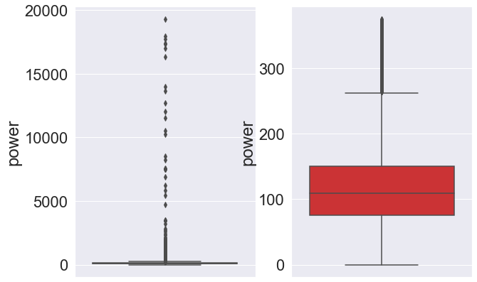

```python
data1 = outliers_proc(data, 'power', scale=3)
```

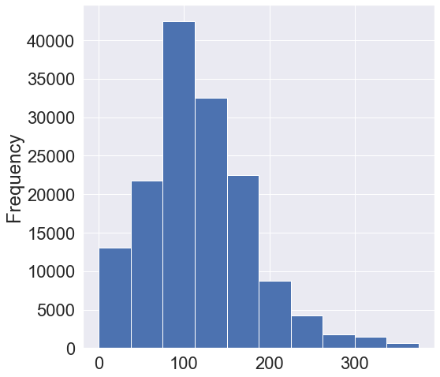

```python
data1['power'].plot.hist()
```

```python
def tanh(x):
    t = (1 - np.exp(-2*x)) / (1 + np.exp(-2*x))
    return t
```

```python
data['power_modi'] = data['power'].apply(lambda x: tanh(x) if x>600 else x)
```

## 特征间相关性分析

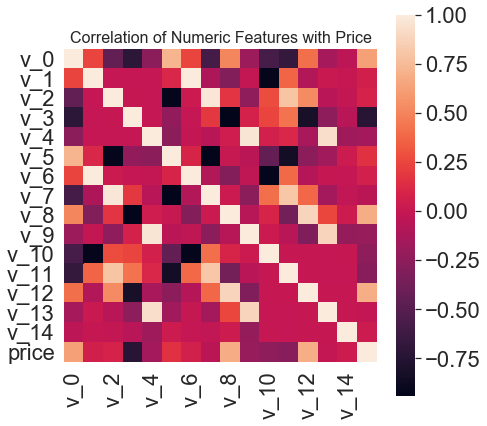

```python
# 当然也可以直接看图
data_numeric = data[['v_0', 'v_1', 'v_2', 'v_3', 'v_4', 'v_5', 'v_6', 'v_7',
                    'v_8', 'v_9', 'v_10', 'v_11', 'v_12', 'v_13', 'v_14', 'price']]
correlation = data_numeric.corr()

f , ax = plt.subplots(figsize = (7, 7))
plt.title('Correlation of Numeric Features with Price',y=1,size=16)
sns.heatmap(correlation,square = True,  vmax=1)
```

```python
correlation
```

|  | v_0 | v_1 | v_2 | v_3 | v_4 | v_5 | v_6 | v_7 | v_8 | v_9 | v_10 | v_11 | v_12 | v_13 | v_14 | price |
| --- | --- | --- | --- | --- | --- | --- | --- | --- | --- | --- | --- | --- | --- | --- | --- | --- |
| v_0 | 1.000000 | 0.245049 | -0.452591 | -0.710480 | -0.259714 | 0.726250 | 0.243783 | -0.584363 | 0.514149 | -0.186243 | -0.582943 | -0.667809 | 0.415711 | -0.136938 | -0.039809 | 0.628397 |
| v_1 | 0.245049 | 1.000000 | -0.001133 | -0.001915 | -0.000468 | 0.109303 | 0.999415 | -0.110806 | -0.298966 | -0.007698 | -0.921904 | 0.370445 | -0.087593 | 0.017349 | 0.002143 | 0.060914 |
| v_2 | -0.452591 | -0.001133 | 1.000000 | 0.001224 | -0.001021 | -0.921857 | 0.023877 | 0.973689 | 0.180285 | -0.236164 | 0.274341 | 0.800915 | 0.535270 | -0.055376 | -0.013785 | 0.085322 |
| v_3 | -0.710480 | -0.001915 | 0.001224 | 1.000000 | -0.001694 | -0.233412 | -0.000747 | 0.191278 | -0.933161 | 0.079292 | 0.247385 | 0.429777 | -0.811301 | -0.246052 | -0.058561 | -0.730946 |
| v_4 | -0.259714 | -0.000468 | -0.001021 | -0.001694 | 1.000000 | -0.259739 | -0.011275 | -0.054241 | 0.051741 | 0.962928 | 0.071116 | 0.110660 | -0.134611 | 0.934580 | -0.178518 | -0.147085 |
| v_5 | 0.726250 | 0.109303 | -0.921857 | -0.233412 | -0.259739 | 1.000000 | 0.091229 | -0.939385 | 0.010686 | -0.050343 | -0.440588 | -0.845954 | -0.258521 | -0.162689 | 0.037804 | 0.164317 |
| v_6 | 0.243783 | 0.999415 | 0.023877 | -0.000747 | -0.011275 | 0.091229 | 1.000000 | -0.085410 | -0.294956 | -0.023057 | -0.917056 | 0.386446 | -0.070238 | 0.000758 | -0.003322 | 0.068970 |
| v_7 | -0.584363 | -0.110806 | 0.973689 | 0.191278 | -0.054241 | -0.939385 | -0.085410 | 1.000000 | 0.028695 | -0.264091 | 0.410014 | 0.813175 | 0.385378 | -0.154535 | -0.020218 | -0.053024 |
| v_8 | 0.514149 | -0.298966 | 0.180285 | -0.933161 | 0.051741 | 0.010686 | -0.294956 | 0.028695 | 1.000000 | -0.063577 | 0.094497 | -0.369353 | 0.882121 | 0.250423 | 0.030416 | 0.685798 |
| v_9 | -0.186243 | -0.007698 | -0.236164 | 0.079292 | 0.962928 | -0.050343 | -0.023057 | -0.264091 | -0.063577 | 1.000000 | 0.026562 | -0.056200 | -0.313634 | 0.880545 | -0.214151 | -0.206205 |
| v_10 | -0.582943 | -0.921904 | 0.274341 | 0.247385 | 0.071116 | -0.440588 | -0.917056 | 0.410014 | 0.094497 | 0.026562 | 1.000000 | 0.006306 | 0.001289 | -0.000580 | 0.002244 | -0.246175 |
| v_11 | -0.667809 | 0.370445 | 0.800915 | 0.429777 | 0.110660 | -0.845954 | 0.386446 | 0.813175 | -0.369353 | -0.056200 | 0.006306 | 1.000000 | 0.006695 | -0.001671 | -0.001156 | -0.275320 |
| v_12 | 0.415711 | -0.087593 | 0.535270 | -0.811301 | -0.134611 | -0.258521 | -0.070238 | 0.385378 | 0.882121 | -0.313634 | 0.001289 | 0.006695 | 1.000000 | 0.001512 | 0.002045 | 0.692823 |
| v_13 | -0.136938 | 0.017349 | -0.055376 | -0.246052 | 0.934580 | -0.162689 | 0.000758 | -0.154535 | 0.250423 | 0.880545 | -0.000580 | -0.001671 | 0.001512 | 1.000000 | 0.001419 | -0.013993 |
| v_14 | -0.039809 | 0.002143 | -0.013785 | -0.058561 | -0.178518 | 0.037804 | -0.003322 | -0.020218 | 0.030416 | -0.214151 | 0.002244 | -0.001156 | 0.002045 | 0.001419 | 1.000000 | 0.035911 |
| price | 0.628397 | 0.060914 | 0.085322 | -0.730946 | -0.147085 | 0.164317 | 0.068970 | -0.053024 | 0.685798 | -0.206205 | -0.246175 | -0.275320 | 0.692823 | -0.013993 | 0.035911 | 1.000000 |

### 特征选择（去除共线特征）

高共线特征 - [colinear feature](http://psychologicalstatistics.blogspot.com/2013/11/multicollinearity-and-collinearity-in.html)在它们之间具有显著的相关系数（接近1或-1）。

虽然数据集中的变量之间通常具有较小的相关性，但高度共线性变量可能是多余的，我们只需要保留其中一个特征即可为模型提供必要的信息。

- 删除共线特征是一种通过减少特征数量来降低模型复杂性的方法，可以增加模型泛化能力。

#### 直接删除高度共线性变量

以下代码

- 通过删除所比较的两个特征之一，根据我们为相关系数选择的阈值来移除共线特征
- 它还打印其删除的相关性，以便我们看到调整阈值的效果。

我们将阈值设置为0.9，如果特征之间的相关系数超过该值，则删除一对特征中的一个。 （仅针对v_系列特征进行筛选）

```python
def remove_collinear_features(x, threshold):
    '''
    Objective:
       删除数据帧中相关系数大于阈值的共线特征。 删除共线特征可以帮助模型泛化并提高模型的可解释性。

    Inputs:
        阈值：删除任何相关性大于此值的特征

    Output:
        仅包含非高共线特征的数据帧
    '''

    # 在数据副本上进行操作
    x = x.copy()

    # 仅对v_系列特征进行处理
    x_numeric = x[['v_0', 'v_1', 'v_2', 'v_3', 'v_4', 'v_5', 'v_6', 'v_7',
                    'v_8', 'v_9', 'v_10', 'v_11', 'v_12', 'v_13', 'v_14']]


    # 计算相关性矩阵
    corr_matrix = x_numeric.corr()
    iters = range(len(corr_matrix.columns) - 1)
    drop_cols = []

    # 迭代相关性矩阵并比较相关性
    for i in iters:
        for j in range(i):
            item = corr_matrix.iloc[j:(j+1), (i+1):(i+2)]
            col = item.columns
            row = item.index
            val = abs(item.values)

            # 如果相关性超过阈值
            if val >= threshold:
                # 打印有相关性的特征和相关值
                print(col.values[0], "|", row.values[0], "|", round(val[0][0], 3))
                drop_cols.append(col.values[0])

    # 删除每对相关列中的一个
    drops = set(drop_cols)
    x = x.drop(columns = drops)

    # 将得分添加回数据


    return x
```

```python
data_modi = remove_collinear_features(data, threshold=0.9)
```

```
v_5 | v_2 | 0.922
v_6 | v_1 | 0.999
v_7 | v_2 | 0.974
v_7 | v_5 | 0.939
v_8 | v_3 | 0.933
v_9 | v_4 | 0.963
v_10 | v_1 | 0.922
v_10 | v_6 | 0.917
v_13 | v_4 | 0.935
```

```python
data_modi
```

[output not shown]

150000 rows × 24 columns

#### TODO:考虑结合降纬的方式减少特征

```python
# 使用T-SNE降纬（我们这里不是简单的删除特征，而是通过降纬的方式减少特征）
from sklearn.manifold import TSNE
```

```python
# v_1\v_6\v_10 降纬
v_col_1 = ['v_1', 'v_6', 'v_10']
matrix = data[v_col_1].values

matrix_tsne = TSNE(n_components=1).fit_transform(matrix)
```

```python
data['v_1_6_10'] = matrix_tsne
```

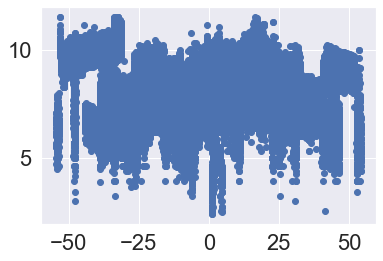

```python
plt.scatter(data['v_1_6_10'], np.log(data['price']))
plt.show()
```

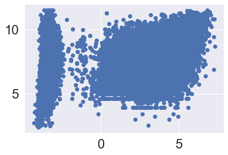

```python
plt.scatter(data['v_1'], np.log(data['price']))
plt.show()
```

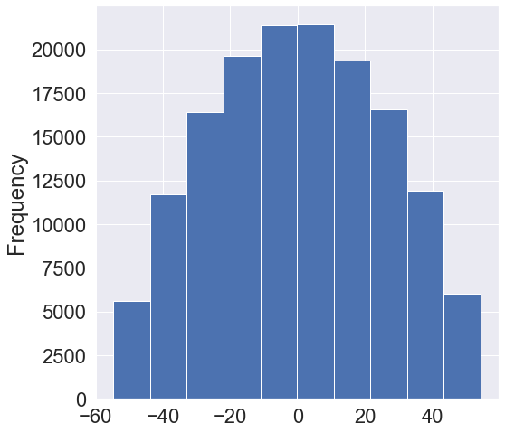

```python
data['v_1_6_10'].plot.hist()
```

## 类别型特征处理

在这一节中，将考虑类别型特征，但不考虑特征`name`、`model`、`regionCode`。

- 通过前面的数据探查，我们发现缺失值存在于特征`notRepairedDamage`、`fuelType`、`gearbox`、`bodyType`、`used_time`
- 我们认为数据发生缺失正好可以描述该车辆存在信息不全的情况，从而影响售价（试想一下，'三无产品'总不太能卖出高价）
- 对于特征`used_time`若进行one-hot编码特征维度将大大提高，我们考虑将特征`used_time`缺失的样本单独处理
- 因此，我们将不对缺失值进行填充，而是作为一种特征，使用one-hot编码方式进行处理

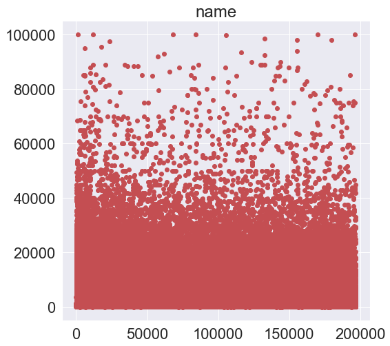

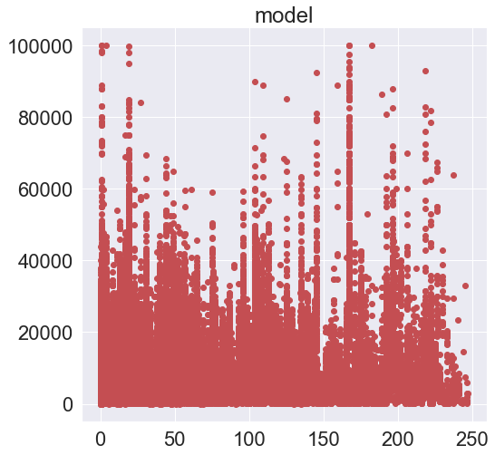

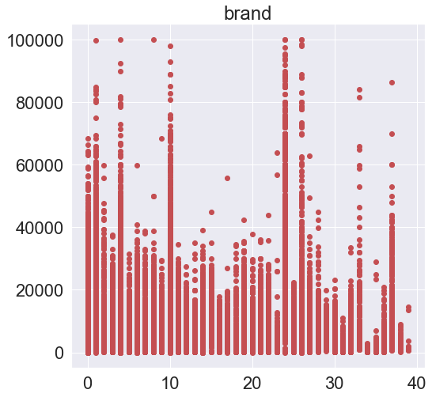

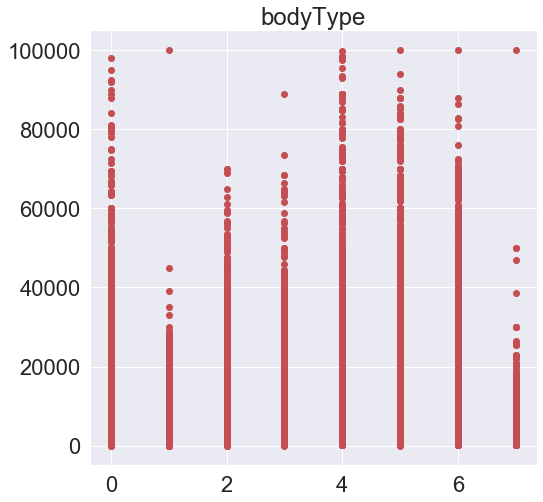

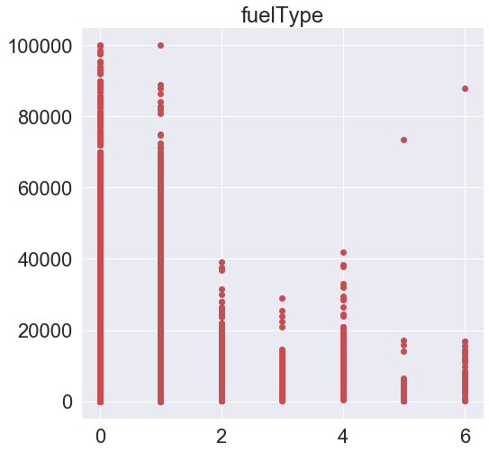

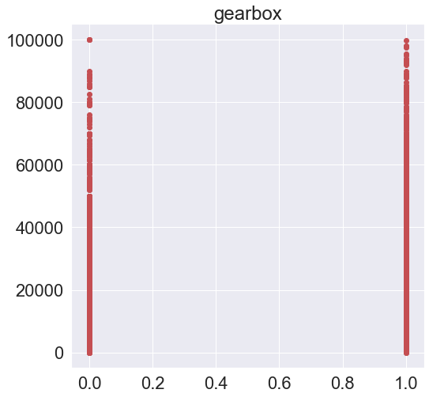

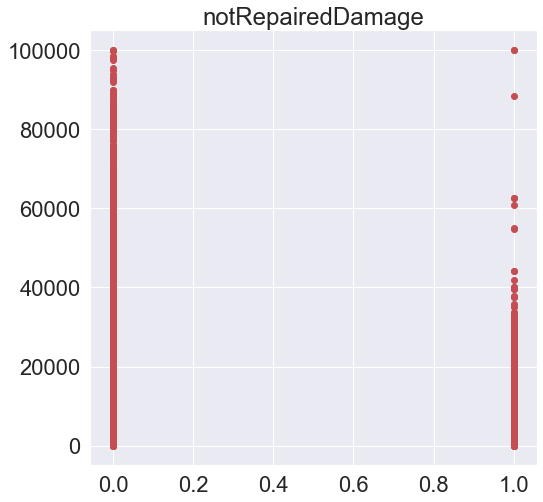

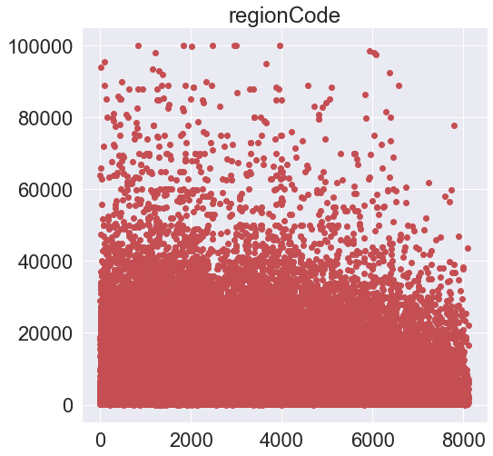

```python
categorical_features = ['name', 'model', 'brand', 'bodyType', 'fuelType', 'gearbox', 'notRepairedDamage', 'regionCode']

for col in categorical_features:
    plt.scatter(data[col], data['price'], c=['r'])
    plt.title(col)
    plt.show()
```

```python
data['loss_info'] = data.isnull().sum(axis=1)
```

```python
data.sort_values('price', ascending=False).tail(20)
```

|  | SaleID | name | regDate | model | brand | bodyType | fuelType | gearbox | power | kilometer | notRepairedDamage | regionCode | creatDate | price | v_0 | v_1 | v_2 | v_3 | v_4 | v_5 | v_6 | v_7 | v_8 | v_9 | v_10 | v_11 | v_12 | v_13 | v_14 | … |
| --- | --- | --- | --- | --- | --- | --- | --- | --- | --- | --- | --- | --- | --- | --- | --- | --- | --- | --- | --- | --- | --- | --- | --- | --- | --- | --- | --- | --- | --- | --- |
| 142768 | 142768 | 108683 | 20050011 | 6.0 | 6 | NaN | NaN | NaN | 0 | 0.5 | NaN | 2777 | 20160307 | 15 | 32.274322 | -3.833896 | 14.485762 | 8.042134 | 1.789435 | 0.000000 | 0.000000 | 1.193391 | 0.0 | 0.070744 | 12.043524 | 16.880029 | -0.920850 | -0.373908 | -1.264339 | … |
| 45599 | 45599 | 144992 | 20020007 | 130.0 | 20 | 2.0 | 0.0 | 1.0 | 120 | 9.0 | NaN | 1700 | 20160326 | 15 | 37.969320 | -3.118148 | -3.459011 | 7.085420 | 3.132758 | 0.222188 | 0.000000 | 0.000000 | 0.0 | 0.177199 | 5.427562 | 1.428470 | -9.223993 | 2.064263 | -0.031276 | … |
| 23621 | 23621 | 158790 | 19960711 | 51.0 | 14 | 0.0 | 0.0 | 0.0 | 136 | 15.0 | 1.0 | 2013 | 20160317 | 15 | 38.271625 | -3.182553 | -3.682251 | 7.775096 | 2.546238 | 0.228350 | 0.000000 | 0.000000 | 0.0 | 0.164204 | 5.401014 | 1.250813 | -9.639552 | 1.212014 | -0.260512 | … |
| 136459 | 136459 | 106249 | 20050012 | 1.0 | 4 | NaN | NaN | NaN | 0 | 0.5 | NaN | 3568 | 20160321 | 15 | 33.213021 | -3.990976 | 14.908158 | 8.863299 | 1.009227 | 0.000000 | 0.000000 | 1.256017 | 0.0 | 0.053368 | 12.010943 | 16.838564 | -0.748998 | -1.621941 | -0.838295 | … |
| 1663 | 1663 | 104033 | 20150002 | 0.0 | 0 | NaN | NaN | NaN | 0 | 0.5 | NaN | 3377 | 20160307 | 15 | 32.975187 | -3.865395 | 14.918919 | 7.336315 | 2.313534 | 0.000000 | 0.000000 | 1.205369 | 0.0 | 0.079990 | 11.823158 | 16.670048 | 0.048213 | 0.215563 | -0.483447 | … |
| 95632 | 95632 | 172834 | 20070008 | 91.0 | 0 | NaN | NaN | NaN | 0 | 8.0 | NaN | 1912 | 20160330 | 15 | 32.590269 | -3.859853 | 14.609711 | 8.174928 | 3.474444 | 0.000000 | 0.000000 | 1.155240 | 0.0 | 0.112157 | 12.029803 | 16.906471 | -0.910445 | 1.004063 | -0.731483 | … |
| 129878 | 129878 | 122198 | 20100002 | 11.0 | 10 | NaN | NaN | NaN | 0 | 0.5 | NaN | 726 | 20160311 | 15 | 33.465972 | -3.976010 | 15.063050 | 8.293492 | 2.107002 | 0.000000 | 0.000000 | 1.231507 | 0.0 | 0.078420 | 11.884577 | 16.722337 | -0.250492 | -0.520462 | -0.827881 | … |
| 15833 | 15833 | 140993 | 20010001 | 67.0 | 0 | 1.0 | 1.0 | NaN | 61 | 15.0 | NaN | 5821 | 20160312 | 15 | 38.978040 | -3.345675 | -2.184581 | 8.175012 | 2.794498 | 0.212750 | 0.000000 | 0.104926 | 0.0 | 0.170780 | 5.649411 | 2.007922 | -8.679290 | 0.901344 | -0.275559 | … |
| 89792 | 89792 | 118882 | 20090006 | 41.0 | 6 | NaN | NaN | NaN | 0 | 6.0 | 0.0 | 3498 | 20160312 | 14 | 31.559888 | -3.725336 | 14.184443 | 7.597646 | 3.472383 | 0.000000 | 0.000000 | 1.115300 | 0.0 | 0.110018 | 12.146427 | 17.042709 | -1.268501 | 1.670326 | -0.023358 | … |
| 37870 | 37870 | 156296 | 20130811 | 53.0 | 4 | 0.0 | 1.0 | 1.0 | 0 | 0.5 | 0.0 | 1202 | 20160327 | 13 | 41.672293 | -3.555951 | -1.962063 | 7.863730 | 1.692640 | 0.234093 | 0.000000 | 0.135699 | 0.0 | 0.138871 | 4.788744 | 0.584751 | -7.100589 | -0.797032 | -0.849644 | … |
| 101457 | 101457 | 6326 | 19970910 | 48.0 | 14 | 1.0 | 0.0 | 0.0 | 60 | 12.5 | 0.0 | 1749 | 20160320 | 13 | 40.906975 | 3.046473 | -1.118624 | 4.389660 | 0.419320 | 0.238500 | 0.084916 | 0.096029 | 0.0 | 0.082651 | -1.102269 | 3.379085 | -5.444485 | 0.029182 | 0.514592 | … |
| 87102 | 87102 | 11244 | 19970206 | 48.0 | 14 | 1.0 | 0.0 | 0.0 | 45 | 15.0 | 1.0 | 1331 | 20160318 | 13 | 37.859230 | -3.243648 | -2.673244 | 8.065651 | 1.269134 | 0.222757 | 0.000000 | 0.072744 | 0.0 | 0.125559 | 5.831949 | 2.173211 | -9.288895 | -0.038460 | -0.327567 | … |
| 141166 | 141166 | 71804 | 20150107 | 1.0 | 26 | NaN | NaN | NaN | 0 | 0.5 | NaN | 4689 | 20160305 | 13 | 34.265979 | -4.094807 | 15.470292 | 8.672858 | 2.238706 | 0.000000 | 0.000000 | 1.261196 | 0.0 | 0.081664 | 11.827376 | 16.671223 | 0.085212 | -0.768994 | -0.315029 | … |
| 101251 | 101251 | 174634 | 19950003 | 0.0 | 0 | NaN | NaN | NaN | 0 | 0.5 | NaN | 501 | 20160402 | 13 | 31.890474 | -3.874060 | 14.232711 | 9.102654 | 0.606629 | 0.000000 | 0.000000 | 1.216252 | 0.0 | 0.045344 | 12.285299 | 17.111173 | -1.848968 | -1.698525 | -1.558972 | … |
| 2947 | 2947 | 110929 | 19950012 | 69.0 | 6 | NaN | NaN | NaN | 0 | 0.5 | NaN | 1452 | 20160313 | 13 | 31.608935 | -3.840686 | 14.086457 | 9.121568 | 1.426882 | 0.000000 | 0.000000 | 1.180628 | 0.0 | 0.065562 | 12.357011 | 17.209102 | -2.137374 | -0.827867 | -1.021263 | … |
| 38310 | 38310 | 178492 | 20150004 | 13.0 | 4 | NaN | NaN | NaN | 0 | 0.5 | NaN | 2135 | 20160311 | 12 | 34.031225 | -4.049277 | 15.372384 | 8.383655 | 2.234355 | 0.000000 | 0.000000 | 1.251174 | 0.0 | 0.081024 | 11.810129 | 16.648497 | 0.129634 | -0.676207 | -0.984519 | … |
| 58839 | 58839 | 143472 | 19970205 | 48.0 | 14 | 1.0 | 0.0 | NaN | 45 | 15.0 | 1.0 | 1331 | 20160320 | 12 | 37.805386 | -3.247609 | -2.698698 | 8.182640 | 1.298059 | 0.222210 | 0.000000 | 0.072249 | 0.0 | 0.126941 | 5.866344 | 2.212414 | -9.404106 | -0.042957 | -0.347455 | … |
| 22197 | 22197 | 2776 | 20150001 | 13.0 | 4 | NaN | NaN | NaN | 0 | 0.5 | NaN | 2135 | 20160307 | 12 | 34.031225 | -4.049277 | 15.372384 | 8.383655 | 2.234355 | 0.000000 | 0.000000 | 1.251174 | 0.0 | 0.081024 | 11.810129 | 16.648497 | 0.129634 | -0.676207 | -0.984519 | … |
| 18756 | 18756 | 74714 | 19951212 | 1.0 | 26 | NaN | NaN | NaN | 0 | 15.0 | NaN | 1271 | 20160404 | 11 | 32.429859 | -3.985785 | 14.477650 | 9.854702 | -0.019091 | 0.000000 | 0.000000 | 1.258931 | 0.0 | 0.031514 | 12.319303 | 17.147857 | -1.918367 | -2.683358 | -1.421036 | … |
| 34859 | 34859 | 34746 | 20050007 | 1.0 | 26 | NaN | NaN | NaN | 0 | 15.0 | NaN | 2920 | 20160305 | 11 | 33.112631 | -4.020578 | 14.862223 | 9.369227 | 0.943838 | 0.000000 | 0.000000 | 1.256404 | 0.0 | 0.052814 | 12.130893 | 16.976255 | -1.141741 | -1.845884 | -0.957988 | … |

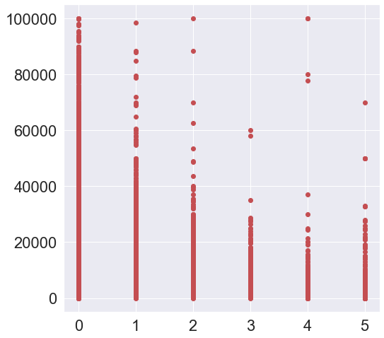

```python
plt.scatter(data['loss_info'], data['price'], c=['r'])
plt.show()
```

```python
data
```

|  | SaleID | name | regDate | model | brand | bodyType | fuelType | gearbox | power | kilometer | notRepairedDamage | regionCode | creatDate | price | v_0 | v_1 | v_2 | v_3 | v_4 | v_5 | v_6 | v_7 | v_8 | v_9 | v_10 | v_11 | v_12 | v_13 | v_14 | … |
| --- | --- | --- | --- | --- | --- | --- | --- | --- | --- | --- | --- | --- | --- | --- | --- | --- | --- | --- | --- | --- | --- | --- | --- | --- | --- | --- | --- | --- | --- | --- |
| 0 | 0 | 736 | 20040402 | 30.0 | 6 | 1.0 | 0.0 | 0.0 | 60 | 12.5 | 0.0 | 1046 | 20160404 | 1850 | 43.357796 | 3.966344 | 0.050257 | 2.159744 | 1.143786 | 0.235676 | 0.101988 | 0.129549 | 0.022816 | 0.097462 | -2.881803 | 2.804097 | -2.420821 | 0.795292 | 0.914762 | … |
| 1 | 1 | 2262 | 20030301 | 40.0 | 1 | 2.0 | 0.0 | 0.0 | 0 | 15.0 | NaN | 4366 | 20160309 | 3600 | 45.305273 | 5.236112 | 0.137925 | 1.380657 | -1.422165 | 0.264777 | 0.121004 | 0.135731 | 0.026597 | 0.020582 | -4.900482 | 2.096338 | -1.030483 | -1.722674 | 0.245522 | … |
| 2 | 2 | 14874 | 20040403 | 115.0 | 15 | 1.0 | 0.0 | 0.0 | 163 | 12.5 | 0.0 | 2806 | 20160402 | 6222 | 45.978359 | 4.823792 | 1.319524 | -0.998467 | -0.996911 | 0.251410 | 0.114912 | 0.165147 | 0.062173 | 0.027075 | -4.846749 | 1.803559 | 1.565330 | -0.832687 | -0.229963 | … |
| 3 | 3 | 71865 | 19960908 | 109.0 | 10 | 0.0 | 0.0 | 1.0 | 193 | 15.0 | 0.0 | 434 | 20160312 | 2400 | 45.687478 | 4.492574 | -0.050616 | 0.883600 | -2.228079 | 0.274293 | 0.110300 | 0.121964 | 0.033395 | 0.000000 | -4.509599 | 1.285940 | -0.501868 | -2.438353 | -0.478699 | … |
| 4 | 4 | 111080 | 20120103 | 110.0 | 5 | 1.0 | 0.0 | 0.0 | 68 | 5.0 | 0.0 | 6977 | 20160313 | 5200 | 44.383511 | 2.031433 | 0.572169 | -1.571239 | 2.246088 | 0.228036 | 0.073205 | 0.091880 | 0.078819 | 0.121534 | -1.896240 | 0.910783 | 0.931110 | 2.834518 | 1.923482 | … |
| ... | ... | ... | ... | ... | ... | ... | ... | ... | ... | ... | ... | ... | ... | ... | ... | ... | ... | ... | ... | ... | ... | ... | ... | ... | ... | ... | ... | ... | ... | … |
| 149995 | 149995 | 163978 | 20000607 | 121.0 | 10 | 4.0 | 0.0 | 1.0 | 163 | 15.0 | 0.0 | 4576 | 20160327 | 5900 | 45.316543 | -3.139095 | -1.269707 | -0.736609 | -1.505820 | 0.280264 | 0.000310 | 0.048441 | 0.071158 | 0.019174 | 1.988114 | -2.983973 | 0.589167 | -1.304370 | -0.302592 | … |
| 149996 | 149996 | 184535 | 20091102 | 116.0 | 11 | 0.0 | 0.0 | 0.0 | 125 | 10.0 | 0.0 | 2826 | 20160312 | 9500 | 45.972058 | -3.143764 | -0.023523 | -2.366699 | 0.698012 | 0.253217 | 0.000777 | 0.084079 | 0.099681 | 0.079371 | 1.839166 | -2.774615 | 2.553994 | 0.924196 | -0.272160 | … |
| 149997 | 149997 | 147587 | 20101003 | 60.0 | 11 | 1.0 | 1.0 | 0.0 | 90 | 6.0 | 0.0 | 3302 | 20160328 | 7500 | 44.733481 | -3.105721 | 0.595454 | -2.279091 | 1.423661 | 0.233353 | 0.000705 | 0.118872 | 0.100118 | 0.097914 | 2.439812 | -1.630677 | 2.290197 | 1.891922 | 0.414931 | … |
| 149998 | 149998 | 45907 | 20060312 | 34.0 | 10 | 3.0 | 1.0 | 0.0 | 156 | 15.0 | 0.0 | 1877 | 20160401 | 4999 | 45.658634 | -3.204785 | -0.441680 | -1.179812 | 0.620680 | 0.256369 | 0.000252 | 0.081479 | 0.083558 | 0.081498 | 2.075380 | -2.633719 | 1.414937 | 0.431981 | -1.659014 | … |
| 149999 | 149999 | 177672 | 19990204 | 19.0 | 28 | 6.0 | 0.0 | 1.0 | 193 | 12.5 | 0.0 | 235 | 20160305 | 4700 | 45.536383 | -3.200326 | -1.612893 | -0.067144 | -1.396166 | 0.284475 | 0.000000 | 0.040072 | 0.062543 | 0.025819 | 1.978453 | -3.179913 | 0.031724 | -1.483350 | -0.342674 | … |

150000 rows × 30 columns

```python
# 删除不考虑的特征
del data['name']
del data['model']
del data['regionCode']
```

```python
data_notRepairedDamage = pd.get_dummies(data['notRepairedDamage'], prefix='notRepairedDamage', dummy_na=True)
data_fuelType = pd.get_dummies(data['fuelType'], prefix='fuelType', dummy_na=True)
data_gearbox = pd.get_dummies(data['gearbox'], prefix='gearbox', dummy_na=True)
data_bodyType = pd.get_dummies(data['bodyType'], prefix='bodyType', dummy_na=True)
```

```python
data = pd.concat([data, data_notRepairedDamage, data_fuelType, data_gearbox, data_bodyType], axis=1)
```

```python
data
```

|  | SaleID | regDate | brand | bodyType | fuelType | gearbox | power | kilometer | notRepairedDamage | creatDate | price | v_0 | v_1 | v_2 | v_3 | v_4 | v_5 | v_6 | v_7 | v_8 | v_9 | v_10 | v_11 | v_12 | v_13 | v_14 | used_time | notRepairedDamage_0.0 | notRepairedDamage_1.0 | … |
| --- | --- | --- | --- | --- | --- | --- | --- | --- | --- | --- | --- | --- | --- | --- | --- | --- | --- | --- | --- | --- | --- | --- | --- | --- | --- | --- | --- | --- | --- | --- |
| 0 | 0 | 20040402 | 6 | 1.0 | 0.0 | 0.0 | 60 | 12.5 | 0.0 | 20160404 | 1850 | 43.357796 | 3.966344 | 0.050257 | 2.159744 | 1.143786 | 0.235676 | 0.101988 | 0.129549 | 0.022816 | 0.097462 | -2.881803 | 2.804097 | -2.420821 | 0.795292 | 0.914762 | 4385.0 | 1 | 0 | … |
| 1 | 1 | 20030301 | 1 | 2.0 | 0.0 | 0.0 | 0 | 15.0 | NaN | 20160309 | 3600 | 45.305273 | 5.236112 | 0.137925 | 1.380657 | -1.422165 | 0.264777 | 0.121004 | 0.135731 | 0.026597 | 0.020582 | -4.900482 | 2.096338 | -1.030483 | -1.722674 | 0.245522 | 4757.0 | 0 | 0 | … |
| 2 | 2 | 20040403 | 15 | 1.0 | 0.0 | 0.0 | 163 | 12.5 | 0.0 | 20160402 | 6222 | 45.978359 | 4.823792 | 1.319524 | -0.998467 | -0.996911 | 0.251410 | 0.114912 | 0.165147 | 0.062173 | 0.027075 | -4.846749 | 1.803559 | 1.565330 | -0.832687 | -0.229963 | 4382.0 | 1 | 0 | … |
| 3 | 3 | 19960908 | 10 | 0.0 | 0.0 | 1.0 | 193 | 15.0 | 0.0 | 20160312 | 2400 | 45.687478 | 4.492574 | -0.050616 | 0.883600 | -2.228079 | 0.274293 | 0.110300 | 0.121964 | 0.033395 | 0.000000 | -4.509599 | 1.285940 | -0.501868 | -2.438353 | -0.478699 | 7125.0 | 1 | 0 | … |
| 4 | 4 | 20120103 | 5 | 1.0 | 0.0 | 0.0 | 68 | 5.0 | 0.0 | 20160313 | 5200 | 44.383511 | 2.031433 | 0.572169 | -1.571239 | 2.246088 | 0.228036 | 0.073205 | 0.091880 | 0.078819 | 0.121534 | -1.896240 | 0.910783 | 0.931110 | 2.834518 | 1.923482 | 1531.0 | 1 | 0 | … |
| ... | ... | ... | ... | ... | ... | ... | ... | ... | ... | ... | ... | ... | ... | ... | ... | ... | ... | ... | ... | ... | ... | ... | ... | ... | ... | ... | ... | ... | ... | … |
| 149995 | 149995 | 20000607 | 10 | 4.0 | 0.0 | 1.0 | 163 | 15.0 | 0.0 | 20160327 | 5900 | 45.316543 | -3.139095 | -1.269707 | -0.736609 | -1.505820 | 0.280264 | 0.000310 | 0.048441 | 0.071158 | 0.019174 | 1.988114 | -2.983973 | 0.589167 | -1.304370 | -0.302592 | 5772.0 | 1 | 0 | … |
| 149996 | 149996 | 20091102 | 11 | 0.0 | 0.0 | 0.0 | 125 | 10.0 | 0.0 | 20160312 | 9500 | 45.972058 | -3.143764 | -0.023523 | -2.366699 | 0.698012 | 0.253217 | 0.000777 | 0.084079 | 0.099681 | 0.079371 | 1.839166 | -2.774615 | 2.553994 | 0.924196 | -0.272160 | 2322.0 | 1 | 0 | … |
| 149997 | 149997 | 20101003 | 11 | 1.0 | 1.0 | 0.0 | 90 | 6.0 | 0.0 | 20160328 | 7500 | 44.733481 | -3.105721 | 0.595454 | -2.279091 | 1.423661 | 0.233353 | 0.000705 | 0.118872 | 0.100118 | 0.097914 | 2.439812 | -1.630677 | 2.290197 | 1.891922 | 0.414931 | 2003.0 | 1 | 0 | … |
| 149998 | 149998 | 20060312 | 10 | 3.0 | 1.0 | 0.0 | 156 | 15.0 | 0.0 | 20160401 | 4999 | 45.658634 | -3.204785 | -0.441680 | -1.179812 | 0.620680 | 0.256369 | 0.000252 | 0.081479 | 0.083558 | 0.081498 | 2.075380 | -2.633719 | 1.414937 | 0.431981 | -1.659014 | 3673.0 | 1 | 0 | … |
| 149999 | 149999 | 19990204 | 28 | 6.0 | 0.0 | 1.0 | 193 | 12.5 | 0.0 | 20160305 | 4700 | 45.536383 | -3.200326 | -1.612893 | -0.067144 | -1.396166 | 0.284475 | 0.000000 | 0.040072 | 0.062543 | 0.025819 | 1.978453 | -3.179913 | 0.031724 | -1.483350 | -0.342674 | 6239.0 | 1 | 0 | … |

150000 rows × 50 columns

```python
# 加入一列用于统计样本缺失值总数
data['miss_info'] = data.isnull().sum(axis=1)
```

```python
data
```

|  | SaleID | regDate | brand | bodyType | fuelType | gearbox | power | kilometer | notRepairedDamage | creatDate | price | v_0 | v_1 | v_2 | v_3 | v_4 | v_5 | v_6 | v_7 | v_8 | v_9 | v_10 | v_11 | v_12 | v_13 | v_14 | used_time | notRepairedDamage_0.0 | notRepairedDamage_1.0 | … |
| --- | --- | --- | --- | --- | --- | --- | --- | --- | --- | --- | --- | --- | --- | --- | --- | --- | --- | --- | --- | --- | --- | --- | --- | --- | --- | --- | --- | --- | --- | --- |
| 0 | 0 | 20040402 | 6 | 1.0 | 0.0 | 0.0 | 60 | 12.5 | 0.0 | 20160404 | 1850 | 43.357796 | 3.966344 | 0.050257 | 2.159744 | 1.143786 | 0.235676 | 0.101988 | 0.129549 | 0.022816 | 0.097462 | -2.881803 | 2.804097 | -2.420821 | 0.795292 | 0.914762 | 4385.0 | 1 | 0 | … |
| 1 | 1 | 20030301 | 1 | 2.0 | 0.0 | 0.0 | 0 | 15.0 | NaN | 20160309 | 3600 | 45.305273 | 5.236112 | 0.137925 | 1.380657 | -1.422165 | 0.264777 | 0.121004 | 0.135731 | 0.026597 | 0.020582 | -4.900482 | 2.096338 | -1.030483 | -1.722674 | 0.245522 | 4757.0 | 0 | 0 | … |
| 2 | 2 | 20040403 | 15 | 1.0 | 0.0 | 0.0 | 163 | 12.5 | 0.0 | 20160402 | 6222 | 45.978359 | 4.823792 | 1.319524 | -0.998467 | -0.996911 | 0.251410 | 0.114912 | 0.165147 | 0.062173 | 0.027075 | -4.846749 | 1.803559 | 1.565330 | -0.832687 | -0.229963 | 4382.0 | 1 | 0 | … |
| 3 | 3 | 19960908 | 10 | 0.0 | 0.0 | 1.0 | 193 | 15.0 | 0.0 | 20160312 | 2400 | 45.687478 | 4.492574 | -0.050616 | 0.883600 | -2.228079 | 0.274293 | 0.110300 | 0.121964 | 0.033395 | 0.000000 | -4.509599 | 1.285940 | -0.501868 | -2.438353 | -0.478699 | 7125.0 | 1 | 0 | … |
| 4 | 4 | 20120103 | 5 | 1.0 | 0.0 | 0.0 | 68 | 5.0 | 0.0 | 20160313 | 5200 | 44.383511 | 2.031433 | 0.572169 | -1.571239 | 2.246088 | 0.228036 | 0.073205 | 0.091880 | 0.078819 | 0.121534 | -1.896240 | 0.910783 | 0.931110 | 2.834518 | 1.923482 | 1531.0 | 1 | 0 | … |
| ... | ... | ... | ... | ... | ... | ... | ... | ... | ... | ... | ... | ... | ... | ... | ... | ... | ... | ... | ... | ... | ... | ... | ... | ... | ... | ... | ... | ... | ... | … |
| 149995 | 149995 | 20000607 | 10 | 4.0 | 0.0 | 1.0 | 163 | 15.0 | 0.0 | 20160327 | 5900 | 45.316543 | -3.139095 | -1.269707 | -0.736609 | -1.505820 | 0.280264 | 0.000310 | 0.048441 | 0.071158 | 0.019174 | 1.988114 | -2.983973 | 0.589167 | -1.304370 | -0.302592 | 5772.0 | 1 | 0 | … |
| 149996 | 149996 | 20091102 | 11 | 0.0 | 0.0 | 0.0 | 125 | 10.0 | 0.0 | 20160312 | 9500 | 45.972058 | -3.143764 | -0.023523 | -2.366699 | 0.698012 | 0.253217 | 0.000777 | 0.084079 | 0.099681 | 0.079371 | 1.839166 | -2.774615 | 2.553994 | 0.924196 | -0.272160 | 2322.0 | 1 | 0 | … |
| 149997 | 149997 | 20101003 | 11 | 1.0 | 1.0 | 0.0 | 90 | 6.0 | 0.0 | 20160328 | 7500 | 44.733481 | -3.105721 | 0.595454 | -2.279091 | 1.423661 | 0.233353 | 0.000705 | 0.118872 | 0.100118 | 0.097914 | 2.439812 | -1.630677 | 2.290197 | 1.891922 | 0.414931 | 2003.0 | 1 | 0 | … |
| 149998 | 149998 | 20060312 | 10 | 3.0 | 1.0 | 0.0 | 156 | 15.0 | 0.0 | 20160401 | 4999 | 45.658634 | -3.204785 | -0.441680 | -1.179812 | 0.620680 | 0.256369 | 0.000252 | 0.081479 | 0.083558 | 0.081498 | 2.075380 | -2.633719 | 1.414937 | 0.431981 | -1.659014 | 3673.0 | 1 | 0 | … |
| 149999 | 149999 | 19990204 | 28 | 6.0 | 0.0 | 1.0 | 193 | 12.5 | 0.0 | 20160305 | 4700 | 45.536383 | -3.200326 | -1.612893 | -0.067144 | -1.396166 | 0.284475 | 0.000000 | 0.040072 | 0.062543 | 0.025819 | 1.978453 | -3.179913 | 0.031724 | -1.483350 | -0.342674 | 6239.0 | 1 | 0 | … |

150000 rows × 51 columns

```python
data = remove_collinear_features(data, threshold=0.9)
```

```
v_5 | v_2 | 0.922
v_6 | v_1 | 0.999
v_7 | v_2 | 0.974
v_7 | v_5 | 0.939
v_8 | v_3 | 0.933
v_9 | v_4 | 0.963
v_10 | v_1 | 0.922
v_10 | v_6 | 0.917
v_13 | v_4 | 0.935
```

```python
data
```

|  | SaleID | regDate | brand | bodyType | fuelType | gearbox | power | kilometer | notRepairedDamage | creatDate | price | v_0 | v_1 | v_2 | v_3 | v_4 | v_11 | v_12 | v_14 | used_time | notRepairedDamage_0.0 | notRepairedDamage_1.0 | notRepairedDamage_nan | fuelType_0.0 | fuelType_1.0 | fuelType_2.0 | fuelType_3.0 | fuelType_4.0 | fuelType_5.0 | … |
| --- | --- | --- | --- | --- | --- | --- | --- | --- | --- | --- | --- | --- | --- | --- | --- | --- | --- | --- | --- | --- | --- | --- | --- | --- | --- | --- | --- | --- | --- | --- |
| 0 | 0 | 20040402 | 6 | 1.0 | 0.0 | 0.0 | 60 | 12.5 | 0.0 | 20160404 | 1850 | 43.357796 | 3.966344 | 0.050257 | 2.159744 | 1.143786 | 2.804097 | -2.420821 | 0.914762 | 4385.0 | 1 | 0 | 0 | 1 | 0 | 0 | 0 | 0 | 0 | … |
| 1 | 1 | 20030301 | 1 | 2.0 | 0.0 | 0.0 | 0 | 15.0 | NaN | 20160309 | 3600 | 45.305273 | 5.236112 | 0.137925 | 1.380657 | -1.422165 | 2.096338 | -1.030483 | 0.245522 | 4757.0 | 0 | 0 | 1 | 1 | 0 | 0 | 0 | 0 | 0 | … |
| 2 | 2 | 20040403 | 15 | 1.0 | 0.0 | 0.0 | 163 | 12.5 | 0.0 | 20160402 | 6222 | 45.978359 | 4.823792 | 1.319524 | -0.998467 | -0.996911 | 1.803559 | 1.565330 | -0.229963 | 4382.0 | 1 | 0 | 0 | 1 | 0 | 0 | 0 | 0 | 0 | … |
| 3 | 3 | 19960908 | 10 | 0.0 | 0.0 | 1.0 | 193 | 15.0 | 0.0 | 20160312 | 2400 | 45.687478 | 4.492574 | -0.050616 | 0.883600 | -2.228079 | 1.285940 | -0.501868 | -0.478699 | 7125.0 | 1 | 0 | 0 | 1 | 0 | 0 | 0 | 0 | 0 | … |
| 4 | 4 | 20120103 | 5 | 1.0 | 0.0 | 0.0 | 68 | 5.0 | 0.0 | 20160313 | 5200 | 44.383511 | 2.031433 | 0.572169 | -1.571239 | 2.246088 | 0.910783 | 0.931110 | 1.923482 | 1531.0 | 1 | 0 | 0 | 1 | 0 | 0 | 0 | 0 | 0 | … |
| ... | ... | ... | ... | ... | ... | ... | ... | ... | ... | ... | ... | ... | ... | ... | ... | ... | ... | ... | ... | ... | ... | ... | ... | ... | ... | ... | ... | ... | ... | … |
| 149995 | 149995 | 20000607 | 10 | 4.0 | 0.0 | 1.0 | 163 | 15.0 | 0.0 | 20160327 | 5900 | 45.316543 | -3.139095 | -1.269707 | -0.736609 | -1.505820 | -2.983973 | 0.589167 | -0.302592 | 5772.0 | 1 | 0 | 0 | 1 | 0 | 0 | 0 | 0 | 0 | … |
| 149996 | 149996 | 20091102 | 11 | 0.0 | 0.0 | 0.0 | 125 | 10.0 | 0.0 | 20160312 | 9500 | 45.972058 | -3.143764 | -0.023523 | -2.366699 | 0.698012 | -2.774615 | 2.553994 | -0.272160 | 2322.0 | 1 | 0 | 0 | 1 | 0 | 0 | 0 | 0 | 0 | … |
| 149997 | 149997 | 20101003 | 11 | 1.0 | 1.0 | 0.0 | 90 | 6.0 | 0.0 | 20160328 | 7500 | 44.733481 | -3.105721 | 0.595454 | -2.279091 | 1.423661 | -1.630677 | 2.290197 | 0.414931 | 2003.0 | 1 | 0 | 0 | 0 | 1 | 0 | 0 | 0 | 0 | … |
| 149998 | 149998 | 20060312 | 10 | 3.0 | 1.0 | 0.0 | 156 | 15.0 | 0.0 | 20160401 | 4999 | 45.658634 | -3.204785 | -0.441680 | -1.179812 | 0.620680 | -2.633719 | 1.414937 | -1.659014 | 3673.0 | 1 | 0 | 0 | 0 | 1 | 0 | 0 | 0 | 0 | … |
| 149999 | 149999 | 19990204 | 28 | 6.0 | 0.0 | 1.0 | 193 | 12.5 | 0.0 | 20160305 | 4700 | 45.536383 | -3.200326 | -1.612893 | -0.067144 | -1.396166 | -3.179913 | 0.031724 | -0.342674 | 6239.0 | 1 | 0 | 0 | 1 | 0 | 0 | 0 | 0 | 0 | … |

150000 rows × 44 columns

```python
del data['regDate']
del data['brand']
del data['bodyType']
del data['fuelType']
del data['gearbox']
del data['notRepairedDamage']
del data['creatDate']
```

```python
data
```

|  | SaleID | power | kilometer | price | v_0 | v_1 | v_2 | v_3 | v_4 | v_11 | v_12 | v_14 | used_time | notRepairedDamage_0.0 | notRepairedDamage_1.0 | notRepairedDamage_nan | fuelType_0.0 | fuelType_1.0 | fuelType_2.0 | fuelType_3.0 | fuelType_4.0 | fuelType_5.0 | fuelType_6.0 | fuelType_nan | gearbox_0.0 | gearbox_1.0 | gearbox_nan | bodyType_0.0 | bodyType_1.0 | … |
| --- | --- | --- | --- | --- | --- | --- | --- | --- | --- | --- | --- | --- | --- | --- | --- | --- | --- | --- | --- | --- | --- | --- | --- | --- | --- | --- | --- | --- | --- | --- |
| 0 | 0 | 60 | 12.5 | 1850 | 43.357796 | 3.966344 | 0.050257 | 2.159744 | 1.143786 | 2.804097 | -2.420821 | 0.914762 | 4385.0 | 1 | 0 | 0 | 1 | 0 | 0 | 0 | 0 | 0 | 0 | 0 | 1 | 0 | 0 | 0 | 1 | … |
| 1 | 1 | 0 | 15.0 | 3600 | 45.305273 | 5.236112 | 0.137925 | 1.380657 | -1.422165 | 2.096338 | -1.030483 | 0.245522 | 4757.0 | 0 | 0 | 1 | 1 | 0 | 0 | 0 | 0 | 0 | 0 | 0 | 1 | 0 | 0 | 0 | 0 | … |
| 2 | 2 | 163 | 12.5 | 6222 | 45.978359 | 4.823792 | 1.319524 | -0.998467 | -0.996911 | 1.803559 | 1.565330 | -0.229963 | 4382.0 | 1 | 0 | 0 | 1 | 0 | 0 | 0 | 0 | 0 | 0 | 0 | 1 | 0 | 0 | 0 | 1 | … |
| 3 | 3 | 193 | 15.0 | 2400 | 45.687478 | 4.492574 | -0.050616 | 0.883600 | -2.228079 | 1.285940 | -0.501868 | -0.478699 | 7125.0 | 1 | 0 | 0 | 1 | 0 | 0 | 0 | 0 | 0 | 0 | 0 | 0 | 1 | 0 | 1 | 0 | … |
| 4 | 4 | 68 | 5.0 | 5200 | 44.383511 | 2.031433 | 0.572169 | -1.571239 | 2.246088 | 0.910783 | 0.931110 | 1.923482 | 1531.0 | 1 | 0 | 0 | 1 | 0 | 0 | 0 | 0 | 0 | 0 | 0 | 1 | 0 | 0 | 0 | 1 | … |
| ... | ... | ... | ... | ... | ... | ... | ... | ... | ... | ... | ... | ... | ... | ... | ... | ... | ... | ... | ... | ... | ... | ... | ... | ... | ... | ... | ... | ... | ... | … |
| 149995 | 149995 | 163 | 15.0 | 5900 | 45.316543 | -3.139095 | -1.269707 | -0.736609 | -1.505820 | -2.983973 | 0.589167 | -0.302592 | 5772.0 | 1 | 0 | 0 | 1 | 0 | 0 | 0 | 0 | 0 | 0 | 0 | 0 | 1 | 0 | 0 | 0 | … |
| 149996 | 149996 | 125 | 10.0 | 9500 | 45.972058 | -3.143764 | -0.023523 | -2.366699 | 0.698012 | -2.774615 | 2.553994 | -0.272160 | 2322.0 | 1 | 0 | 0 | 1 | 0 | 0 | 0 | 0 | 0 | 0 | 0 | 1 | 0 | 0 | 1 | 0 | … |
| 149997 | 149997 | 90 | 6.0 | 7500 | 44.733481 | -3.105721 | 0.595454 | -2.279091 | 1.423661 | -1.630677 | 2.290197 | 0.414931 | 2003.0 | 1 | 0 | 0 | 0 | 1 | 0 | 0 | 0 | 0 | 0 | 0 | 1 | 0 | 0 | 0 | 1 | … |
| 149998 | 149998 | 156 | 15.0 | 4999 | 45.658634 | -3.204785 | -0.441680 | -1.179812 | 0.620680 | -2.633719 | 1.414937 | -1.659014 | 3673.0 | 1 | 0 | 0 | 0 | 1 | 0 | 0 | 0 | 0 | 0 | 0 | 1 | 0 | 0 | 0 | 0 | … |
| 149999 | 149999 | 193 | 12.5 | 4700 | 45.536383 | -3.200326 | -1.612893 | -0.067144 | -1.396166 | -3.179913 | 0.031724 | -0.342674 | 6239.0 | 1 | 0 | 0 | 1 | 0 | 0 | 0 | 0 | 0 | 0 | 0 | 0 | 1 | 0 | 0 | 0 | … |

150000 rows × 37 columns

```python
data.to_csv('processed_data_forModel.csv', index=False)
```

```python
data.columns.shape
```

[output not shown]

```python
feature_need_to_drop = ['regDate', 'power', 'regionCode', 'creatDate',
                        'Date_End']
train_data = data.copy()
train_data.drop(feature_need_to_drop, axis=1, inplace=True)
```

```python
train_data.to_csv('train_data_for_xgboost.csv', index=0)
```

```python
features = train_data.drop(['price', 'SaleID'], axis=1)

targets = pd.DataFrame(train_data['price'])

# 用 nan 替换 inf and -inf （required for later imputation）
features = features.replace({np.inf: np.nan, -np.inf: np.nan})

X, X_test, y, y_test = train_test_split(features, targets, test_size = 0.3, random_state = 42)

print(X.shape)
print(X_test.shape)
print(y.shape)
print(y_test.shape)
```

```
(105000, 25)
(45000, 25)
(105000, 1)
(45000, 1)
```

```python
features.shape
```

```
(150000, 25)
```

```python
# 评估函数MAE
def mae(y_true, y_pred):
    return np.mean(abs(y_true - y_pred))
```

```python
# 接受模型，训练模型，并在测试集上评估模型

def fit_and_evaluate(model):

    # 训练模型
    model.fit(X,y)

    # 做出预测和评估
    model_pred = model.predict(X_test)
    model_mae = mae(y_test,model_pred)

    # 返回性能指标
    return model_mae
```

```python
# 输入缺失值和缩放值
from sklearn.impute import SimpleImputer

from sklearn.ensemble import RandomForestRegressor, GradientBoostingRegressor
```

```python
# 使用中位数填充策略创建一个SimpleImputer
imputer = SimpleImputer(missing_values=np.nan, strategy='median')

imputer.fit(X)

# 转换训练数据和测试数据
X = imputer.transform(X)
X_test = imputer.transform(X_test)
```

```python
print('Missing values in training features:', np.sum(np.isnan(X)))
print('Missing values in testing features:',np.sum(np.isnan(X_test)))
```

```
Missing values in training features: 0
Missing values in testing features: 0
```

```python
# Make sure all values are finite
# 确保所有值都是有限的

print(np.sum(~np.isfinite(X)))
print(np.sum(~np.isfinite(X_test)))
```

```
0
0
```

```python
# Convert y to one-dimensional array (vector)
y = np.array(y).reshape((-1, ))
y_test = np.array(y_test).reshape((-1, ))
```

```python
# 随机森林
random_forest = RandomForestRegressor(random_state = 60)
random_forest_mae = fit_and_evaluate(random_forest)

print('Random Forest Regression Performance on the test set: MAE = %0.4f' % random_forest_mae)
```

```
Random Forest Regression Performance on the test set: MAE = 628.0446
```

```python
test['used_time'] = (pd.to_datetime(test['creatDate'], format='%Y%m%d', errors='coerce') -
                            pd.to_datetime(test['regDate'], format='%Y%m%d', errors='coerce')).dt.days
```

```python
test.head()
```

|  | SaleID | name | regDate | model | brand | bodyType | fuelType | gearbox | power | kilometer | notRepairedDamage | regionCode | seller | offerType | creatDate | v_0 | v_1 | v_2 | v_3 | v_4 | v_5 | v_6 | v_7 | v_8 | v_9 | v_10 | v_11 | v_12 | v_13 | … |
| --- | --- | --- | --- | --- | --- | --- | --- | --- | --- | --- | --- | --- | --- | --- | --- | --- | --- | --- | --- | --- | --- | --- | --- | --- | --- | --- | --- | --- | --- | --- |
| 0 | 150000 | 66932 | 20111212 | 222.0 | 4 | 5.0 | 1.0 | 1.0 | 313 | 15.0 | 0.0 | 1440 | 0 | 0 | 20160329 | 49.593127 | 5.246568 | 1.001130 | -4.122264 | 0.737532 | 0.264405 | 0.121800 | 0.070899 | 0.106558 | 0.078867 | -7.050969 | -0.854626 | 4.800151 | 0.620011 | … |
| 1 | 150001 | 174960 | 19990211 | 19.0 | 21 | 0.0 | 0.0 | 0.0 | 75 | 12.5 | 1.0 | 5419 | 0 | 0 | 20160404 | 42.395926 | -3.253950 | -1.753754 | 3.646605 | -0.725597 | 0.261745 | 0.000000 | 0.096733 | 0.013705 | 0.052383 | 3.679418 | -0.729039 | -3.796107 | -1.541230 | … |
| 2 | 150002 | 5356 | 20090304 | 82.0 | 21 | 0.0 | 0.0 | 0.0 | 109 | 7.0 | 0.0 | 5045 | 0 | 0 | 20160308 | 45.841370 | 4.704178 | 0.155391 | -1.118443 | -0.229160 | 0.260216 | 0.112081 | 0.078082 | 0.062078 | 0.050540 | -4.926690 | 1.001106 | 0.826562 | 0.138226 | … |
| 3 | 150003 | 50688 | 20100405 | 0.0 | 0 | 0.0 | 0.0 | 1.0 | 160 | 7.0 | 0.0 | 4023 | 0 | 0 | 20160325 | 46.440649 | 4.319155 | 0.428897 | -2.037916 | -0.234757 | 0.260466 | 0.106727 | 0.081146 | 0.075971 | 0.048268 | -4.864637 | 0.505493 | 1.870379 | 0.366038 | … |
| 4 | 150004 | 161428 | 19970703 | 26.0 | 14 | 2.0 | 0.0 | 0.0 | 75 | 15.0 | 0.0 | 3103 | 0 | 0 | 20160309 | 42.184604 | -3.166234 | -1.572058 | 2.604143 | 0.387498 | 0.250999 | 0.000000 | 0.077806 | 0.028600 | 0.081709 | 3.616475 | -0.673236 | -3.197685 | -0.025678 | … |

```python
feature_need_to_drop = ['regDate', 'power', 'regionCode', 'creatDate',
                       'seller', 'offerType']
test_data = test.copy()
test_data.drop(feature_need_to_drop, axis=1, inplace=True)
```

```python
test_data.to_csv('test_data_for_xgboost.csv', index=0)
```

```python
features = test_data.drop(['SaleID'], axis=1)
```

```python
features.columns.shape
```

```
(25,)
```

```python
features.replace('-', np.nan, inplace=True)
```

```python
imputer.fit(features)

features = imputer.transform(features)
```

```python
y_pre = random_forest.predict(features)
```

```python
res = pd.DataFrame()
res['SaleID'] = test_data['SaleID']
res['price'] = y_pre
res.to_csv('res.csv', index=False)
```

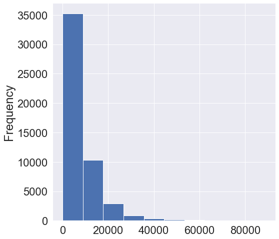

```python
res['price'].plot.hist()
```